# The DFT of a Pitch Class Set

Aubin Bannwarth  
24/08/2021

### A web-application for mathematical music theory

- [Visit application](https://aubinbannwarth.shinyapps.io/pcs_dft_widget/)

### Motivation

- The *discrete Fourier transform*, or *DFT*, well known to engineers, mathematicians, and anyone who has studied digital signal processing, has recently found applications in the field of music theory.
- Unfortunately, not many students of music theory will possess the mathematical or scientific programming skills involved in calculating DFTs.
- This application allows a musician to create any *pitch class set*, or *PCS*, by selecting notes on a more familiar construct, the circle of fifths, and see its DFT and characteristic function instantly.
- By playing around with the app, and looking at the DFTs and characteristic functions, one can hope to find new insights into the structure of music.

### Implementation I

- A *Notes.csv* file was prepared, with each observation representing a pitch class identified by the **Class** variable. Other variables includes the class' common musical **Name**, its order **c5_order** in the circle of fifths and the x and y coordinates of its position in the circle (**c5_x**, **c5_y**).

```r
library(tidyverse)
Notes <- read_csv('Notes.csv')
```

```r
kable(Notes)
```

| Class | Name | c5_order | c5_x | c5_y |
| --- | --- | --- | --- | --- |
| 0 | C/B# | 0 | 0.0000000 | 1.0000000 |
| 1 | C#/Db | 5 | -0.5000000 | -0.8660254 |
| 2 | D | 10 | 0.8660254 | 0.5000000 |
| 3 | D#/Eb | 3 | -1.0000000 | 0.0000000 |
| 4 | E/Fb | 8 | 0.8660254 | -0.5000000 |
| 5 | F/E# | 1 | -0.5000000 | 0.8660254 |
| 6 | F#/Gb | 6 | 0.0000000 | -1.0000000 |
| 7 | G | 11 | 0.5000000 | 0.8660254 |
| 8 | G#/Ab | 4 | -0.8660254 | -0.5000000 |
| 9 | A | 9 | 1.0000000 | 0.0000000 |
| 10 | A#/Bb | 2 | -0.8660254 | 0.5000000 |
| 11 | B/Cb | 7 | 0.5000000 | -0.8660254 |

### Implementation II

- Using the **Notes** data set and the **ggplot** package, one can easily create a visualisation of the circle of fifths.
- From there, it is a simple exercise in reactive programming to transform this visualisation into an input selection device; and the **Notes** data set contains all of the information required to calculate the DFT.

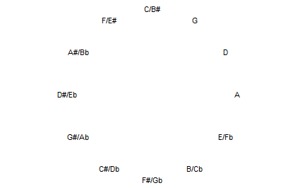

```r
Notes %>% ggplot() +
  geom_text(aes(c5_x, c5_y, label = Name)) +
  coord_fixed() + theme_void() + xlim(-1.2, 1.2)
```

### Further work and references

- For the purposes of this course project, creating inputs by clicking on a reactive graph of the circle of fifths was part of the challenge, but it is not the most efficient. In the future, I may add additional input methods, such as typing in a full PCS, or selecting from a [list of existing PCS](https://en.wikipedia.org/wiki/List_of_pitch-class_sets).
- It could also pay to add some additional plots, such as the imaginary parts of the DFT and characteristic function, or the individual Fourier components.
- A more advanced feature could allow the calculation of the convolution of two pitch class sets, and more.
- For more information, visit the app's [documentation page](https://aubinbannwarth.github.io/pcs_dft_widget/help.html).